# Bike Sharing Case Study 2024

Yasin Karadag

2025-06-30

## Data Preparation

### 1. Downloading Data Files

The dataset includes 12 `.csv` files, one for each month.  
You can download the monthly trip data from the following link:

👉 [Divvy Trip Data](https://divvy-tripdata.s3.amazonaws.com/index.html)

### 2. Merging Data Files into One File Using Postgres

All monthly files were imported into PostgreSQL as individual tables:

- `trip_data202401` to `trip_data202412`

These were combined into one single table with PostSQL.

```sql
CREATE TABLE trip_data_combined AS
SELECT * FROM trip_data202401
UNION ALL
SELECT * FROM trip_data202402
UNION ALL
SELECT * FROM trip_data202403
UNION ALL
SELECT * FROM trip_data202404
UNION ALL
SELECT * FROM trip_data202405
UNION ALL
SELECT * FROM trip_data202406
UNION ALL
SELECT * FROM trip_data202407
UNION ALL
SELECT * FROM trip_data202408
UNION ALL
SELECT * FROM trip_data202409
UNION ALL
SELECT * FROM trip_data202410
UNION ALL
SELECT * FROM trip_data202411
UNION ALL
SELECT * FROM trip_data202412
```

### 3. Creating ride_duration Column

```sql
ALTER TABLE trip_data_combined
ADD COLUMN ride_duration INTERVAL;
```

### 4. Calculating and Updating ride_duration

```sql
UPDATE trip_data_combined
SET ride_duration = ended_at - started_at;
```

### 5. Adding ride_duration_seconds Column

```sql
ALTER TABLE trip_data_combined
ADD COLUMN ride_duration_seconds INT;
```

### 6. Calculating and Updating ride_duration_seconds Column

```sql
UPDATE trip_data_combined
SET ride_duration_seconds = EXTRACT(EPOCH FROM ride_duration);
```

## Data Cleaning

Below are the key steps performed to clean the data set before analysis:

### 1.Check for Missing Values in `member_casual` Column

- Verified that there are no missing (`NA`) values in the `member_casual` column.

```r
sum(is.na(df$member_casual))
```

### 2.Remove Entries with Zero or Negative Ride Duration

- Identified 917 entries where ride_duration was zero or negative.
- These rows were removed from the dataset.

### 3.Remove Rides Longer Than 24 Hours

- Filtered out entries where ride_duration_seconds > 86400 seconds (24 hours).

```r
df <- df %>%
  filter(ride_duration_seconds <= 86400)
```

### 4.Remove Duplicate Entries (Same ride_id)

- Found and removed duplicate entries based on the ride_id column.

```r
df <- df %>%
  distinct(ride_id, .keep_all = TRUE)
```

### 5.Remove missing (`NA`) values in started_at column

```r
df <- df %>% filter(!is.na(started_at))
```

## Analyze

### Analysis of Average Ride Duration by User Type

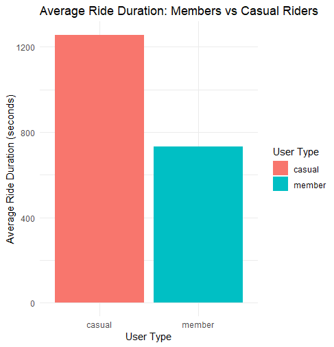

From the bar chart above, we observe:

- Casual riders have an average ride duration of around 1200 seconds (20 minutes).
- Members tend to have shorter rides, averaging around 700 seconds (11-12 minutes).
- This difference may be due to factors such as casual riders using bikes for leisure, while members may use them for daily commuting.

I generate the bar chart using the `ggplot2` package.

[figure not shown]

```r
library(dplyr)
library(gt)

pivot_table <- df %>%
  group_by(member_casual) %>%
  summarise(avg_ride_duration = mean(ride_duration_sec, na.rm = TRUE))
pivot_table %>%
  gt() %>%
  tab_header(
    title = "Average Ride Duration by User Type"
  ) %>%
  cols_label(
    member_casual = "User Type",
    avg_ride_duration = "Average Ride Duration (sec)"
  ) %>%
  fmt_number(
    columns = c(avg_ride_duration),
    decimals = 2
  )

# Visualize the Data

library(ggplot2)

ggplot(pivot_table, aes(x = member_casual, y = avg_ride_duration, fill = member_casual)) +
  geom_bar(stat = "identity") +
  theme_minimal() +
  labs(title = "Average Ride Duration: Members vs Casual Riders",
       x = "User Type",
       y = "Average Ride Duration (seconds)") +
  scale_fill_discrete(name = "User Type")
```

The above plot reveals key trends in ride duration across different user types:

- Casual riders have an average ride duration of approximately 1200 seconds, indicating longer, possibly leisure-based rides.
- Members, on the other hand, show an average ride duration around 700 seconds, suggesting shorter, more utilitarian trips (likely daily commuting).
- The difference in ride duration implies a contrast in how each user type engages with the bike-sharing service.

```r
# Calculate average ride duration by member type and weekday
pivot_data <- df %>%
  group_by(member_casual, day_of_week) %>%
  summarise(avg_ride_length = mean(ride_duration_sec, na.rm = TRUE)) %>%
  ungroup()

# Visualize
ggplot(pivot_data, aes(x = day_of_week, y = avg_ride_length, fill = member_casual)) +
  geom_col(position = "dodge") +
  geom_text(
    aes(label = round(avg_ride_length, 1)),
    position = position_dodge(width = 0.9),
    vjust = -0.3,
    size = 3
  ) +
  scale_fill_manual(values = c("member" = "#1f77b4", "casual" = "#ff7f0e")) +
  labs(
    title = "Average Ride Duration by User Type and Day of Week",
    x = "Day of Week",
    y = "Avg. Ride Duration (seconds)",
    fill = "User Type"
  ) +
  theme_minimal(base_size = 13) +
  theme(
    plot.title = element_text(face = "bold", hjust = 0.5),
    legend.position = "top"
  )
```

[output not shown]

## Analysis of Rides by User Type and Day of the Week

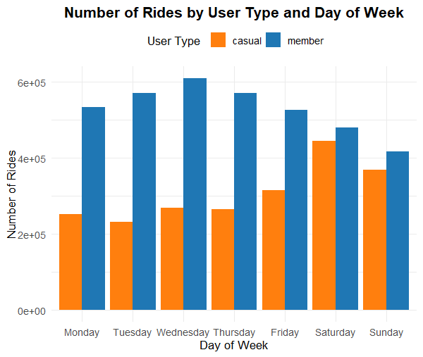

The bar chart illustrates the number of rides taken by casual riders and members across different days of the week.

### Key Observations:

- Weekdays (Monday to Friday):
  - Members consistently have a higher number of rides compared to casual users.
  - This trend suggests that members primarily use the service for daily commuting or regular trips.
- Weekends (Saturday and Sunday):
  - The number of rides taken by casual users increases significantly, closing the gap between the two user groups.
  - This indicates that casual riders tend to use bikes more for leisure and recreational activities on weekends.

```r
# 1. Create the Pivot Table (Count of rides)
pivot_data_count <- df %>%
  group_by(member_casual, day_of_week) %>%
  summarise(ride_count = n()) %>%
  ungroup()
#  2. Visualize the Pivot Table (Bar Chart)
ggplot(pivot_data_count, aes(x = day_of_week, y = ride_count, fill = member_casual)) +
  geom_col(position = "dodge") +
  labs(
    title = "Number of Rides by User Type and Day of Week",
    x = "Day of Week",
    y = "Number of Rides",
    fill = "User Type"
  ) +
  scale_fill_manual(values = c("member" = "#1f77b4", "casual" = "#ff7f0e")) +
  theme_minimal(base_size = 13) +
  theme(
    plot.title = element_text(face = "bold", hjust = 0.5),
    legend.position = "top"
  )
```

### Top 10 Most Used Start Stations

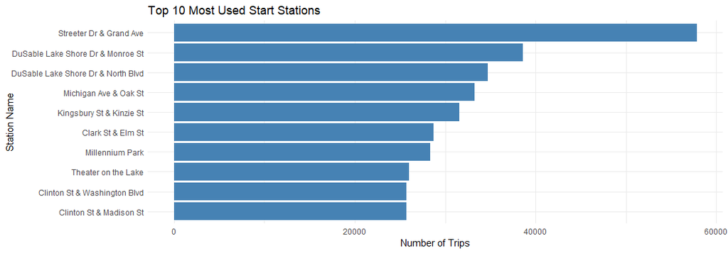

[figure not shown]

```r
# TOP 10 Stations

library(leaflet)
library(dplyr)
library(ggplot2)

## Code for bar plot
top_stations_geo <- df %>%
  filter(!is.na(start_station_name), !is.na(start_lat), !is.na(start_lng)) %>%
  group_by(start_station_name, start_lat, start_lng) %>%
  summarise(trip_count = n(), .groups = "drop") %>%
  arrange(desc(trip_count)) %>%
  slice_head(n = 10)

## Code for geoplot
ggplot(top_stations_geo , aes(x = reorder(start_station_name, trip_count), y = trip_count)) +
  geom_col(fill = "steelblue") +
  coord_flip() +
  labs(
    title = "Top 10 Most Used Start Stations",
    x = "Station Name",
    y = "Number of Trips"
  ) +
  theme_minimal()


leaflet(top_stations_geo) %>%
  addTiles() %>%
  addCircleMarkers(
    lng = ~start_lng,
    lat = ~start_lat,
    label = ~paste0(start_station_name, ": ", trip_count, " rides"),
    radius = ~sqrt(trip_count) / 0,
    color = "blue",
    fillOpacity = 0.7
  ) %>%
  addLegend("bottomright", colors = "blue", labels = "Start Stations", title = "Legend")
```

### Conclusion

Understanding these ride duration trends can help bike-sharing services optimize pricing, bike availability, and service offerings. Further analyses could explore seasonal trends or geographic variations to enhance user experience.